# Data Structures in R

# Welcome to R for Biologists Workshop!

[figure not shown]

# Workflow

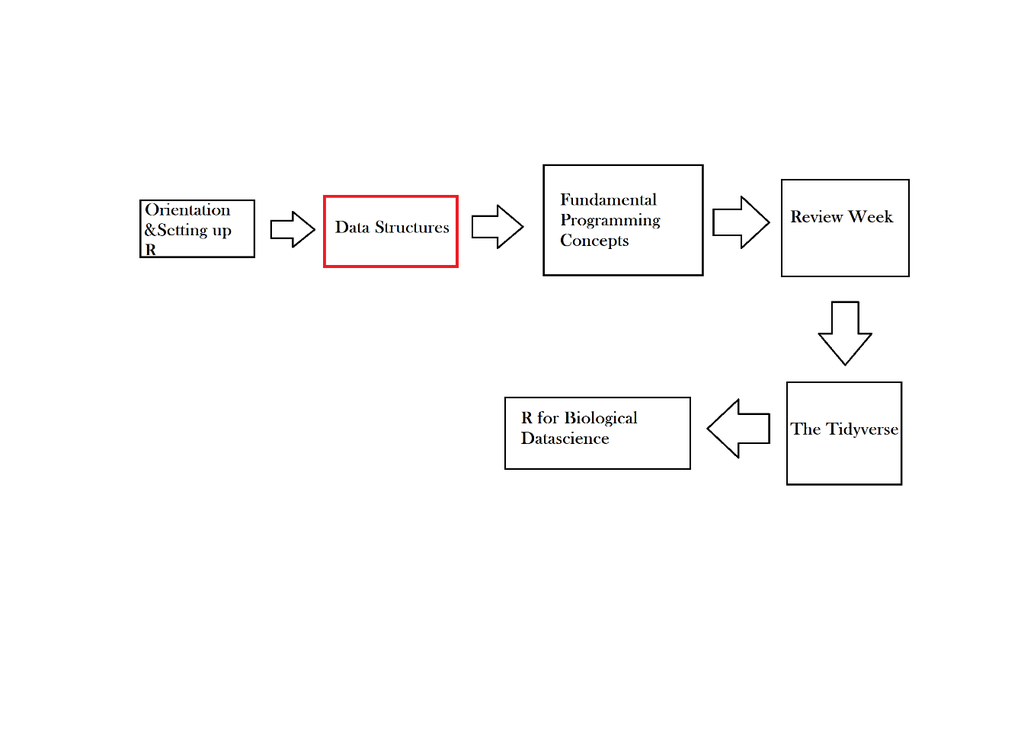

# Real world example of basic skills

Lets say we have two sequences

Sequence 1

```r
print(seq1)
```

```
## [1] "agagacacagccgaaccccaggcagttttggccggtttgccaggttccccgttaccgtcctt"
```

& Sequence 2

```r
print(seq2)
```

```
## [1] "agagacacagccgaaccccaggcagttttggccgctttgccaggttccccgttaccgtcctt"
```

And you want to know whether the first sequencing file is the same as the second.

**Are the 2 sequences the same?**

```r
seq1==seq2
```

```
## [1] FALSE
```

# Comments

An important tool for writing R code is comments. These are preceded by # and are ignored by R

```r
#This code will say "Hello World!"

"Hello world!"
```

```
## [1] "Hello world!"
```

Comments are a helpful tool for conveying information about your code to others.

# 5 basic data structures in R

- Character
- Numeric
- Integer
- Logical
- Complex

## Character

Holds “string” data. For example:

```r
"Hello World"
```

```
## [1] "Hello World"
```

You can ask R to tell you what type of data you have:

```r
class("Hello World")
```

```
## [1] "character"
```

## Numbers

Numbers can be integers or numerics (i.e., floats) in R. For example:

```r
1
```

```
## [1] 1
```

```r
2.2
```

```
## [1] 2.2
```

```r
3E100
```

```
## [1] 3e+100
```

The default for R is to make every number a numeric

```r
class(1)
```

```
## [1] "numeric"
```

Which means that we have hidden decimal points behind the 1 (1.00 for example)

### Specifying an integer

But what if we wanted specifically an integer?

```r
1L
```

```
## [1] 1
```

```r
class(1L)
```

```
## [1] "integer"
```

### Challenge Question 1

Is this a numeric or a character?

```r
"2"
```

```
## [1] "2"
```

**What is the class(“2”)**

```r
class("2")
```

```
## [1] "character"
```

## Logicals

Logicals are either True of False. For example

```r
TRUE
```

```
## [1] TRUE
```

```r
FALSE
```

```
## [1] FALSE
```

```r
class(TRUE)
```

```
## [1] "logical"
```

```r
class(FALSE)
```

```
## [1] "logical"
```

…its time for another challenge question!

### Challenge question 2

R is *case sensitive*.

With that knowledge, what do you think the below would give us?

**What is the class(true)**

```r
class(true)
```

```
## Error in eval(expr, envir, enclos): object 'true' not found
```

## Data Structure Classes cont..

So far we have only been using class()

But we can also use a function to see the structure of any R object:

```r
str(1)
```

```
##  num 1
```

```r
str("Hello World!")
```

```
##  chr "Hello World!"
```

```r
str(TRUE)
```

```
##  logi TRUE
```

### Challenge Question 3

R is an object oriented language, and it tends to put everything in some sort of class. What would the below tell us?

```r
str(class)
```

**What is the str(class)**

```
## function (x)
```

# Simple Data Structures Methods

## Arithmetic Methods

- Addition

```r
1+1
```

```
## [1] 2
```

- Subraction

```r
1-1
```

```
## [1] 0
```

- Multiplication

```r
2*2
```

```
## [1] 4
```

- Division

```r
10/2
```

```
## [1] 5
```

## Equivalence Comparisons

Equivalence comparisons are a way to check if any two objects are the same

```r
#Does 1 equal 1?

1==1
```

```
## [1] TRUE
```

```r
#Does "Hello" equal "World?"

"Hello" == "World"
```

```
## [1] FALSE
```

We can also invert an equivalancy comparison to check if two objects are *not* equal

```r
#Does 1 not equal 1?

1!=1
```

```
## [1] FALSE
```

## Mathematical Comparisons

For numeric data types, mathematical comparisons can also be made

```r
#Is 1 less than 100?
1<100
```

```
## [1] TRUE
```

```r
#Is 2+2 greater than 2^2

2+2>2^2
```

```
## [1] FALSE
```

### Challenge Question 4

Arithmetic in R follows PEMDAS

```r
4+5*3
```

```
## [1] 19
```

vs

```r
(4+5)*3
```

```
## [1] 27
```

What would we get with the following?

```r
4+5*3>(4+5)*3
```

**What would you get with 4+5x3>(4+5)x3**

```
## [1] FALSE
```

# Variables

Variables hold objects that are assigned to them.

```r
a <- 1
```

They can be identical to the object assigned to them

```r
a <- 1
b <- a

#does b equal 1?

b==1
```

```
## [1] TRUE
```

Variables enable complex operations on data

```r
h <- 2^100
i <- h/3E100
j <- 1E5
k <- j^(-1*i)

#is k greater than 1?

k < 1
```

```
## [1] FALSE
```

# Complex Data Structures

## Vectors

A Vector is an ordered collection of either numerics, characters, or logicals

```r
c(1, 2, 3)
```

```
## [1] 1 2 3
```

```r
c(TRUE, FALSE, TRUE)
```

```
## [1]  TRUE FALSE  TRUE
```

```r
c("hello", "world")
```

```
## [1] "hello" "world"
```

### Challenge Question 5

A vector in R has a limitation: they can only allow one type of class in each vector.

If you add more than one type of class, it will default to a character.

With that said, what would the following give you?

[output not shown]

**What is the class of (c(“puppies”, 2))**

```r
class(c("puppies", 2))
```

```
## [1] "character"
```

### Challenge Question 6

I can change the following vector in my variable to all numbers

```r
my_num <- as.numeric(c("2", 2))

class(my_num)
```

```
## [1] "numeric"
```

But what would happen if I tried to do the following?

```r
as.numeric(c("salt", "2"))

print(as.numeric(c("salt", "2")))
```

**What is the class of as.numeric(c(“salt”, “2”))**

```
## [1] NA  2
```

[output not shown]

# Vectors Continued

Vectors can also have a vector of names which describe each element

```r
grades <- c(98, 95, 82)
names(grades) <- c("Jimmy", "Alice", "Susan")

grades
```

```
## Jimmy Alice Susan
##    98    95    82
```

Elements from a vector can be accessed using the index of the desired data. Lets say I wanted to know what Alice’s grade was.

```r
grades[2]
```

```
## Alice
##    95
```

But lets say that I didn’t know Alice was the second index

```r
grades["Alice"]
```

```
## Alice
##    95
```

If you want to add a series of numbers to a vector of integers, you can do the following:

```r
my_ints <- 1:10
my_ints
```

```
##  [1]  1  2  3  4  5  6  7  8  9 10
```

# Lists

A list is an ordered collection of any objects. This differs from vectors, because vectors can only be one type of object class

```r
my_list <- list(1, "b", TRUE, c(1,2,3))
my_list
```

```
## [[1]]
## [1] 1
##
## [[2]]
## [1] "b"
##
## [[3]]
## [1] TRUE
##
## [[4]]
## [1] 1 2 3
```

Lists can also have names

```r
names(my_list)=c("My #", "My Letter", "My logical", "My_num_Set")

my_list
```

```
## $`My #`
## [1] 1
##
## $`My Letter`
## [1] "b"
##
## $`My logical`
## [1] TRUE
##
## $My_num_Set
## [1] 1 2 3
```

The elements within a list can be accessed by using numeric indexes or by the element name

```r
my_list[[2]]
```

```
## [1] "b"
```

```r
my_list[["My_num_Set"]]
```

```
## [1] 1 2 3
```

```r
my_list$My_num_Set
```

```
## [1] 1 2 3
```

```r
#If I did the following, I would get the whole vector within the list

my_list[2]
```

```
## $`My Letter`
## [1] "b"
```

Data frames are similar to excel sheets. They are 2D arrays which can hold numeric, character, and boolean data. They also have column names.

```r
my_df <- data.frame("students"=c("Jimmy", "Alice", "Susan"),
                    "Grades"=c(98, 95, 82))


my_df
```

```
##   students Grades
## 1    Jimmy     98
## 2    Alice     95
## 3    Susan     82
```

Data frames can be accessed numerically by expressing the row and column of interest.

```r
#What grade did Susan get?

my_df[3,2] #row, column
```

```
## [1] 82
```

They can also be accessed with the $ sign

```r
my_df$Grades
```

```
## [1] 98 95 82
```

```r
#What grade did Alice get?

my_df$Grades[2]
```

```
## [1] 95
```

# End of the workshop

Thank you!

Questions?